# Integration of omics and clinical data of the hormonal, metabolic, inflammatory, and oxidative response in the different macronutrients of the diet

Statistical Descriptive analysis of Intestinal Permeability Biomarkers

Edmond Geraud

15 de noviembre, 2021

```r
> list.of.packages <- c("xlsx", "kableExtra", "dplyr", "ggplot2", "egg", "cowplot",
+     "patchwork", "gridExtra", "UsingR", "car", "lattice", "ggpubr", "ggbreak", "GGally",
+     "reshape2", "ggcorrplot", "corrplot", "rela", "ggrepel", "factoextra")
> new.packages <- list.of.packages[!(list.of.packages %in% installed.packages()[, "Package"])]  ## check for packages not installed
> if (length(new.packages)) install.packages(new.packages)  ## install packages if necessary
> res <- unlist(lapply(list.of.packages, require, character.only = T))  ## load packages needed for the session
> if (any(res == F)) {
+     list.of.packages[which(res == F)]  ## show those package if you have troubles to install.
+ }
>
> list.of.bioc.packages <- c("phyloseq", "pcaMethods")
> new.packages.bioc <- list.of.packages[!(list.of.bioc.packages %in% installed.packages()[,
+     "Package"])]
> if (length(new.packages.bioc)) BiocManager::install(new.packages.bioc)
> res.bioc <- unlist(lapply(list.of.bioc.packages, require, character.only = T))
> if (any(res.bioc == F)) {
+     list.of.packages[which(res.bioc == F)]  ## show those package if you have troubles to install.
+ }
```

```r
> resumen <- function(x) {
+     c(round(mean(x), 4), round(sd(x), 4))
+ }  # Function that help us to summarize the data in mean and sd values
> lowerFn <- function(data, mapping, method = "lm", ...) {
+     p <- ggplot(data = data, mapping = mapping) + geom_point(colour = "blue") + geom_smooth(method = method,
+         color = "red", ...)
+     p
+ }
>
> ## Function that takes variable names and the labels for the axis.
> bp.1.vars <- function(datos_, vars, y_lab) {
+
+     datos <- cbind(datos_[, c("GROUP", "OBESE")], datos_[, vars])
+     df.melt <- melt(datos, id.vars = c("GROUP", "OBESE"))
+
+     # print(head(df.melt))
+
+
+     p2 <- ggplot(df.melt, aes(y = value, x = variable, fill = GROUP)) + geom_boxplot() +
+         ylab(y_lab) + facet_grid(~OBESE) + xlab("") + geom_hline(yintercept = 0,
+         linetype = "dashed", color = "red")
+
+
+     return(p2)
+
+ }
>
> plotPCA_scores <- function(X, factor, title, size = 1.5, glineas = 0.25, center_,
+     scale_, labels) {
+
+     pcX <- prcomp(X, center = center_, scale. = scale_)
+     X.scores <- pcX$x
+     rot <- round(pcX$sdev^2/sum(pcX$sdev^2) * 100, 2)
+
+     # scores
+     X.scores <- as.data.frame(X.scores)
+     Group <- factor[[1]]
+     Group2 <- factor[[2]]
+     colores <- 1:length(levels(Group))
+     # main plot
+     p1 <- ggplot(X.scores, aes(x = PC1, y = PC2)) + theme_classic() + geom_hline(yintercept = 0,
+         color = "gray70") + geom_vline(xintercept = 0, color = "gray70") + geom_point(aes(color = Group,
+         shape = Group2), alpha = 0.55, size = 3) + coord_cartesian(xlim = c(min(X.scores[,
+         1]) - 5, max(X.scores[, 1]) + 5)) + scale_fill_discrete(name = "Group")
+     # avoiding labels superposition
+
+     grafico <- p1 + geom_text_repel(aes(y = PC2 + 0.25, label = labels), segment.size = 0.25,
+         size = size) + labs(x = c(paste("PC1", rot[1], "%")), y = c(paste("PC2",
+         rot[2], "%"))) + ggtitle(paste("Principal Component Analysis for: ", title,
+         sep = " ")) + theme(plot.title = element_text(hjust = 0.5)) + scale_color_manual(values = colores)
+
+
+
+
+     return(list(pcX, grafico))
+ }
```

# Summary of the univariate descrpitve analysis.

## Overall study.

The data comprises 53 subjects, which are divided into 34 females and 19 males. From the 34 females, 18 are non obese and 16 obese. And 10 non obese males and 9 obese males. The 18 non obese females are divided into 9 PCOS and 9 healthy. The 16 obese females are divided further into 8 PCOS and 8 non PCOS.

A sanity check of the study was performed to observed possibly differences between the groups. No differences were found. Descriptive numerical tables were performed on each data-set except on the microbiome. Numerical descriptive tables only contain the mean and the standard deviation.

For each numerical variable (all except the ones that describes the groups) their distribution were analyzed as a whole, without taking into account the groups (obese, sex and PCOS).

It has to be mentioned that no correlation between variables on the different data types were performed. Only uni variate statistical analysis on each data set was performed.

Permeability markers, and some clinical biomarkers, were analyzed at basal and postprandial times. The first day of the study corresponds to the glucose oral load, the second to the lipids and the third to the proteins.

**Permability Biomarkers:** Apart from the categorical variables, we have sCD14, LBP, zonulin and succinate. Each variable the mean basal value is computed,as well as the basal values for each day and the postprandial stage. Succinate is more like a metabolite, however, it was calculated in other units, and we do not know how to include this metablolite. ( No units are specified on this data set)

## Intestinal permeability markers.

As mentioned above, this data set comprises of four permeability markers and one metabolite. As we did on the clinical biomarkers, firstly we did a quick review of the literature.

CD14 (Cluster differentiation 14), is a protein that detects bacteria in the body by binding a lipopolysacharide *This should be interesting when integrating the data sets*. Also this binding its only possible with the *Lipopolysacharide-binding-protein LBP*. Also recognize other pathogen associated molecular patterns. LBP is important to cell surface pattern recongition such as CD14 and TLR4 (mentioned on the references).

GLP2 (Glucagon-like peptide2) decreases cytokine expression, and is part of the inflammatory response. Is reported than Zonulin increases in patients with diabetes mellitus II.

On the other hand, succinate, as mentioned, is a metabolite, involved in many pathways, activates the inflammatory response trough toll like receptors (mentioned on the main references).

A correlation-scatter matrix plot was performed to observe the relationships among the mean basal values of the variables, BMI included, as is an indicator of diabetes II and inflammation.

BMI, correlates positively with all variables, except on sCD14. SCD14, correlates in a positve manner with LBP and Zonulin, as described in the literature, and negatively with GLP2 and succinate.

The correlation of LBP with GLP2, zonulin and succinate is positive. There is no relationship between GLP2 and zonulin, but a positive correlation exist between succinate. Finally succinate and zonulin present a barely positive correlation.

**Comparison between basal and postpranidal levels.**

All variables on this data set, show higher values at basal level than at postprandial time SCD14, at basal levels is higher on non-obese subjects. Specially on healthy control women. No distinction between the other groups is found regarding non-obese subjects. Obese PCOS women show increased levels of this IP, but lower than healthy control women. At postprandial levels, similar values are found across all subjects. But on the second and third day, on non-obese subjects males and PCOS women show higher values. Obese males at the first day show the highest values at postprandial levels.

LBP mean basal values are higher on obese subjects, specifically on PCOS obese women. And no distinction between groups are observed at postprandial levels, GLP values are higher at basal levels on obese PCOS women and obese males. Between control women no distinction is observed. At postprandial levels, higher values are observed on the second and third day. With no distinction between non-obese subjects. Obese control subjects show higher values than obese PCOS women.

Succinate levels are higher on obese subjects, but remarkably higher on obese women with PCOS. At postprandial time, the first day, levels of this metabolite are higher. Being higher on non obese males and obese PCOS women. On the other days no distinction is found between groups

## Description of Intestinal Permeability Markers.

Read the file of IP

```r
> IP_file <- file.path(params$folder.data, file = params$file.data)  ## file path of the data
> IP.tmp <- read.xlsx(IP_file, sheetIndex = 1)
```

Observe the structure of the data

```r
> str(IP.tmp)  # show general description of the data
```

```
'data.frame':   53 obs. of  42 variables:
 $ Orden             : num  1 2 3 4 5 6 7 8 9 10 ...
 $ Paciente          : chr  "MdGLP2" "MdGLP3" "MdGLP4" "MdGLP5" ...
 $ SEX               : num  0 0 0 0 0 0 0 0 0 0 ...
 $ GROUP             : num  0 0 0 0 0 0 0 0 0 0 ...
 $ OBESE             : num  0 0 0 0 0 0 0 0 0 1 ...
 $ BMI               : num  25.2 24.4 23.9 25.3 21 ...
 $ IP.markers...     : logi  NA NA NA NA NA NA ...
 $ CD14_basalmean    : num  1993 1385 2003 1322 1279 ...
 $ G_CD14_0          : num  2086 1516 2120 1363 1317 ...
 $ L_CD14_0          : num  2020 1260 2044 1437 1205 ...
 $ P_CD14_0          : num  1873 1379 1846 1165 1314 ...
 $ AUC_CD14_Glu      : num  -103.3 -64 -220.8 -84.1 21.9 ...
 $ AUC_CD14_Lipids   : num  -123.1 -43.2 -179.5 -77.6 -28.9 ...
 $ AUC_CD14_Prots    : num  -134.3 -82 -184.7 -67.6 -62.8 ...
```

[output cut: 28 more lines]

```r
> IP <- IP.tmp[, -7]  # remove the missin values column
> IP$SEX <- factor(IP$SEX, levels = c(0, 2), labels = c("Female", "Male"))
> IP$OBESE <- factor(IP$OBESE, levels = c(0, 1), labels = c("No Obese", "Obese"))
> IP$GROUP <- factor(IP$GROUP, levels = c(0, 1, 2), labels = c("Female", "PCOS", "Male"))
> # all(IP$Paciente == general_data$Paciente) # sanity check.  str(IP)
```

The data comprises the following permeability markers.

1. CD14

2. LBP

Lipopolysaccharide binding protein: LBP is a soluble acute-phase protein that binds to bacterial lipopolysaccharide (or LPS) to elicit immune responses by presenting the LPS to important cell surface pattern recognition receptors called CD14 and TLR4. The protein encoded by this gene is involved in the acute-phase immunologic response to gram-negative bacterial infections. The protein encoded by this gene is involved in the acute-phase immunologic response to gram-negative bacterial infections. The proinflammatory activity of plasma LPS is increased by LPB, which is higher in obesity Lipopolysaccharide-binding protein has been shown to interact with CD14, TLR2, TLR4 and the co-receptor MD-2

3. GLP2

Glucagon-like peptide 2 (GLP-2) is a 33 amino acid peptide-encoded carboxyterminal to the sequence of GLP-1 in the proglucagon gene. Both GLP-1 and GLP-2 are secreted from gut endocrine cells and promote nutrient absorption through distinct mechanisms of action. GLP-2 regulates gastric motility, gastric acid secretion, intestinal hexose transport, and increases the barrier function of the gut epithelium. GLP-2 reduces mortality and decreases mucosal injury, cytokine expression, and bacterial septicemia in the setting of small and large bowel inflammation.

4. Zonulin

Zonulin (haptoglobin 2 precursor) is a protein that modulates the permeability of tight junctions between cells of the wall of the digestive tract. Type 2 diabetic patients have shown increased zonulin

5. Succinate

Activation of inflammatory macrophages through toll-like receptors induces a metabolic shift towards glycolysis…..Actually is a metabolite

For each intestinal permeability marker, it is measured at basal stage and mean, for each day corresponding to every marcronutrient load. For each day they only measured values at basal time and at 60 minutes or 120 minutes, depending if it the load was lipids or not.

### Description of the variables

| Variable | Description |
| --- | --- |
| Orden | Order of the subjects |
| Paciente | Women contol (M),PCOS women (P),Male (V), d (Not obese), O (Obese), GLP (challenge macronutrients: glucose, lipids, proteins) |
| SEX | 0 Women, 2 Male |
| GROUP | 0 Women Control, 1 PCOS, 2 Male |
| OBESE | 0 Not obese, 1 Obese |
| BMI | Body Mass Index |
| CD14_basalmean | Mean basal concentration: Cluster differentiation 14 (CD14) |
| G_CD14_0 | Basal time Glucose load day: Cluster differentiation 14 |
| L_CD14_0 | Basal time Lipid load day: Cluster differentiation 14 |
| P_CD14_0 | Basal time Protein load day: Cluster differentiation 14 |
| AUC_CD14_Glu | Postprandial time Area Under the Curve Glucose load day: Cluster differentiation 14 |
| AUC_CD14_Lipids | Postprandial time Area Under the Curve Lipids load day: Cluster differentiation 14 |
| AUC_CD14_Prots | Postprandial time Area Under the Curve Rroteins load day: Cluster differentiation 14 |
| LBP_basalmean | Mean basal concentration: Lipopolysaccharide binding protein |
| G_LBP__0 | Basal time Glucose load day: Lipopolysaccharide binding protein |
| L_LBP_0 | Basal time Lipid load day: Lipopolysaccharide binding protein |
| P_LBP_0 | Basal time Protein load day: Lipopolysaccharide binding protein |
| AUC_LBP_Glu | Postprandial time Area Under the Curve Glucose load day: Lipopolysaccharide binding protein |
| AUC_LBP_Lipids | Postprandial time Area Under the Curve Lipids load day: Lipopolysaccharide binding protein |
| AUC_LBP_Prots | Postprandial time Area Under the Curve Proteins load day: Lipopolysaccharide binding protein |
| GLP2_basalmean | Mean basal concentration: Glucagon-like peptide 2 |
| G_GLP2_0 | Basal time Glucose load day: Glucagon-like peptide 2 |
| L_GLP2_0 | Basal time Lipid load day: Glucagon-like peptide 2 |
| P_GLP2_0 | Basal time Protein load day: Glucagon-like peptide 2 |
| AUC_GLP2_Glu | Postprandial time Area Under the Curve Glucose load day: Glucagon-like peptide 2 |
| AUC_GLP2_Lipids | Postprandial time Area Under the Curve Lipids load day: Glucagon-like peptide 2 |
| AUC_GLP2_Prots | Postprandial time Area Under the Curve Proteins load day: Glucagon-like peptide 2 |
| Zonulin_basalmean | Mean basal concentration: zonulin |
| G_Zonulin_0 | Basal time Glucose load day: zonulin |
| L_Zonulin_0 | Basal time Lipid load day: zonulin |
| P_Zonulin_0 | Basal time Protein load day: zonulin |
| AUC_Zonulin_Glu | Postprandial time Area Under the Curve Glucose load day: zonulin |
| AUC_Zonulin_Lipids | Postprandial time Area Under the Curve Lipids load day: zonulin |
| AUC_Zonulin_Prots | Postprandial time Area Under the Curve Rroteins load day: zonulin |
| Succin_basalmean | Mean basal concentration: Succinate* |
| G_Succinate_0 | Basal time Glucose load day: Succinate* |
| L_Succinate_0 | Basal time Lipid load day: Succinate |
| P_Succinate_0 | Basal time Protein load day: Succinate* |
| AUC_Succ_Glu | Postprandial time Area Under the Curve Glucose load day: Succinate* |
| AUC_Succ_Lipids | Postprandial time Area Under the Curve Lipids load day: Succinate* |
| AUC_Succ_Prots | Postprandial time Area Under the Curve Rroteins load day: Succinate* |

### Sanity check: Statistical description of categorical variables.

```r
> (sexo <- table(IP$SEX))
```

```
Female   Male
    34     19
```

```r
> (sexo.obesos <- table(IP$SEX, IP$OBESE))
```

```
         No Obese Obese
  Female       18    16
  Male         10     9
```

```r
> (subgrupos <- table(IP$GROUP, IP$OBESE))
```

```
         No Obese Obese
  Female        9     8
  PCOS          9     8
  Male         10     9
```

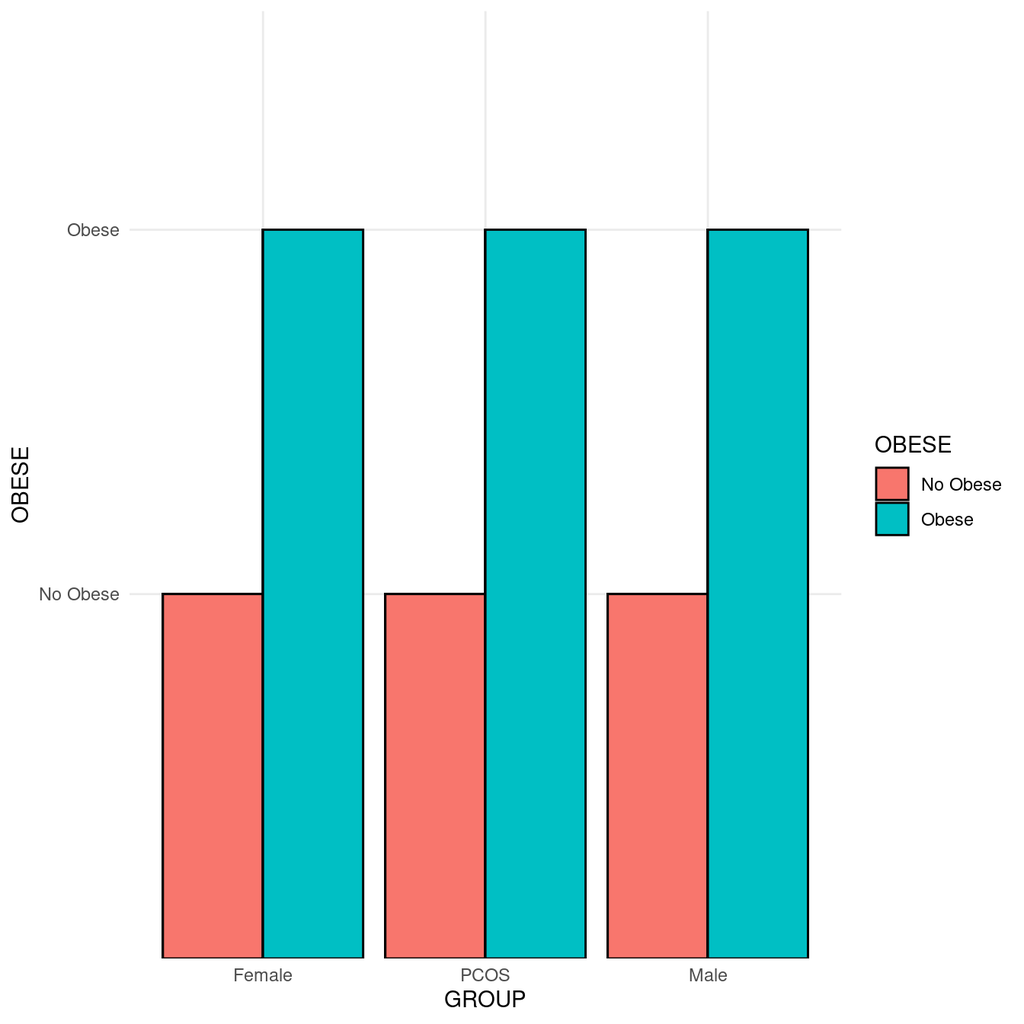

```r
> ggplot(data = IP, aes(x = GROUP, y = OBESE, fill = OBESE)) + geom_bar(stat = "identity",
+     color = "black", position = position_dodge()) + theme_minimal()
```

### Univariate descriptive analysis of IP markers

#### Numerical descriptive analysis

Before starting with the graphical statistical analysis, we are going to perform a numerical descriptive analysis.

```r
> IP.variables <- IP[, 3:ncol(IP)]  ## remove samples names and order from the summary adn BMI variable, we have already described
>
>
>
> IP.sum <- IP.variables %>%
+     group_by(GROUP, OBESE) %>%
+     summarise(across(where(is.numeric), resumen), n = n())  # Group the data by variable GROUP and OBESE
>
> d.f <- as.data.frame(t(IP.sum))[c(nrow(t(IP.sum)), 1:(nrow(t(IP.sum)) - 1)), ]  # transpose the data for visualization purposes and get rid off the N value for same purposes
> d.f_final <- d.f[-c(1:4), ]  # remove categorical variables.
> nombre_variables <- c("Mean basal value sCD14", "Basal gluclose load sCD14", "Basal lipid load sCD14",
+     "Basal protein load sCD14", "Postprandial AUC glucose sCD14", "Postprandial AUC lipid sCD14",
+     "Postptrandial AUC protien sCD14", "Mean basal value LBP", "Basal gluclose load LBP",
+     "Basal lipid load LBP", "Basal protein load LBP", "Postprandial AUC glucose LBP",
+     "Postprandial AUC lipid LBP", "Postptrandial AUC protien LBP", "Mean basal value GLP2",
+     "Basal gluclose load GLP2", "Basal lipid load GLP2", "Basal protein load GLP2",
+     "Postprandial AUC glucose GLP2", "Postprandial AUC lipid GLP2", "Postptrandial AUC protien GLP2",
+     "Mean basal value zonulin", "Basal gluclose load zonulin", "Basal lipid load zonulin",
+     "Basal protein load zonulin", "Postprandial AUC glucose zonulin", "Postprandial AUC lipid zonulin",
+     "Postptrandial AUC protien zonulin", "Mean basal value Succinate", "Basal gluclose load Succinate",
+     "Basal lipid load Succinate", "Basal protein load Succinate", "Postprandial AUC glucose Succinate",
+     "Postprandial AUC lipid Succinate", "Postptrandial AUC protien Succinate")
> code_variables <- colnames(IP)[7:ncol(IP)]
> d.f_final$Coda <- code_variables
> rownames(d.f_final) <- nombre_variables
> N <- as.character(d.f_final[1, ])
> colnames(d.f_final) <- rep(c("Mean", "SD"), 6)
> ## ATTENION! Because assining left hand expression is complicated, just for one
> ## table, be careful if we put another data-set For showing the number of
> ## subjects by group
> kbl(d.f_final) %>%
+     kable_classic_2() %>%
+     add_header_above(c(` ` = 1, `9` = 2, `8` = 2, `9` = 2, `8` = 2, `10` = 2, `9` = 2,
+         ` ` = 1)) %>%
+     add_header_above(c(` ` = 1, `No Obese` = 2, Obese = 2, `No Obese` = 2, Obese = 2,
+         `No Obese` = 2, Obese = 2, ` ` = 1)) %>%
+     add_header_above(c(` ` = 1, `Control Females` = 4, PCOS = 4, `Control Males` = 4,
+         ` ` = 1))
```

|  | Control Females No Obese 9 Mean | Control Females No Obese 9 SD | Control Females Obese 8 Mean | Control Females Obese 8 SD | PCOS No Obese 9 Mean | PCOS No Obese 9 SD | PCOS Obese 8 Mean | PCOS Obese 8 SD | Control Males No Obese 10 Mean | Control Males No Obese 10 SD | Control Males Obese 9 Mean | Control Males Obese 9 SD | NA |
| --- | --- | --- | --- | --- | --- | --- | --- | --- | --- | --- | --- | --- | --- |
| Mean basal value sCD14 | 1622.5261 | 356.5516 | 1349.7967 | 158.8634 | 1376.2645 | 196.6155 | 1395.7067 | 172.3018 | 1461.5674 | 242.9235 | 1218.0166 | 157.4821 | CD14_basalmean |
| Basal gluclose load sCD14 | 1616.4624 | 349.8042 | 1333.7816 | 168.4803 | 1423.1199 | 233.2102 | 1392.2961 | 176.9743 | 1463.6046 | 265.0928 | 1162.2384 | 183.3443 | G_CD14_0 |
| Basal lipid load sCD14 | 1655.8413 | 405.9859 | 1371.4295 | 194.7483 | 1353.0536 | 200.7818 | 1408.3769 | 189.8384 | 1506.8241 | 261.6239 | 1236.0972 | 229.2819 | L_CD14_0 |
| Basal protein load sCD14 | 1595.2744 | 367.4139 | 1344.1790 | 165.2242 | 1352.6200 | 194.0364 | 1386.4470 | 225.4545 | 1414.2734 | 286.7836 | 1255.7140 | 179.9206 | P_CD14_0 |
| Postprandial AUC glucose sCD14 | -56.1973 | 77.4846 | -28.3863 | 55.1671 | -36.2074 | 52.4368 | -29.7306 | 52.2264 | -32.7964 | 36.2741 | 33.7088 | 39.5681 | AUC_CD14_Glu |
| Postprandial AUC lipid sCD14 | -84.4713 | 57.1696 | -16.6339 | 53.2657 | -28.3982 | 44.5100 | -36.6638 | 82.2585 | -40.1553 | 41.6922 | 3.8733 | 69.5343 | AUC_CD14_Lipids |
| Postptrandial AUC protien sCD14 | -98.0867 | 49.2649 | -51.2976 | 31.3058 | -43.9022 | 37.8522 | -14.9436 | 54.4789 | -57.1272 | 34.0438 | -45.1625 | 35.6676 | AUC_CD14_Prots |
| Mean basal value LBP | 14.5063 | 3.9187 | 17.1758 | 6.3192 | 13.6726 | 4.3476 | 20.2325 | 5.5702 | 12.9157 | 3.6946 | 15.7200 | 3.1449 | LBP_basalmean |
| Basal gluclose load LBP | 15.1011 | 4.8719 | 16.5275 | 5.8494 | 15.3789 | 6.2652 | 22.0963 | 8.3714 | 13.3500 | 4.4614 | 16.4289 | 5.8221 | G_LBP__0 |
| Basal lipid load LBP | 13.0578 | 3.0594 | 16.7637 | 7.1225 | 12.2644 | 4.8389 | 17.8612 | 4.1472 | 12.3020 | 3.2331 | 14.6611 | 2.9071 | L_LBP_0 |
| Basal protein load LBP | 15.3600 | 5.1337 | 18.2362 | 6.8080 | 13.3744 | 3.6118 | 20.7400 | 5.6448 | 13.0950 | 4.0520 | 16.0700 | 3.7453 | P_LBP_0 |
| Postprandial AUC glucose LBP | -0.1317 | 0.8140 | -0.9265 | 0.7372 | -0.3022 | 1.4394 | -1.2529 | 2.2374 | -0.3090 | 0.5528 | -0.8716 | 1.3133 | AUC_LBP_Glu |
| Postprandial AUC lipid LBP | -0.2498 | 0.6463 | -0.1228 | 1.1640 | -0.2127 | 0.6613 | -0.5353 | 0.8948 | 0.1962 | 0.8161 | 0.3350 | 0.8249 | AUC_LBP_Lipids |
| Postptrandial AUC protien LBP | -0.4287 | 0.7232 | -0.7905 | 1.0928 | -0.3676 | 0.5004 | -0.4198 | 1.3305 | -0.1748 | 0.2542 | -0.3362 | 0.5015 | AUC_LBP_Prots |
| Mean basal value GLP2 | 4.3389 | 0.5959 | 4.1139 | 0.9500 | 3.5320 | 0.5337 | 4.8804 | 0.7538 | 4.4905 | 0.8161 | 5.6117 | 2.2787 | GLP2_basalmean |
| Basal gluclose load GLP2 | 4.3351 | 0.6167 | 4.3015 | 0.9050 | 3.5233 | 0.4210 | 4.9144 | 1.2117 | 4.4622 | 0.7839 | 5.3298 | 2.3742 | G_GLP2_0 |
| Basal lipid load GLP2 | 4.0220 | 0.8972 | 4.0030 | 1.1086 | 3.2943 | 0.7586 | 4.9675 | 1.1091 | 4.3727 | 0.6915 | 5.6951 | 2.1038 | L_GLP2_0 |
| Basal protein load GLP2 | 4.6594 | 0.8143 | 4.0372 | 1.0740 | 3.7782 | 0.6181 | 4.7592 | 0.5321 | 4.6367 | 1.2211 | 5.8103 | 2.5258 | P_GLP2_0 |
| Postprandial AUC glucose GLP2 | -0.0507 | 0.8050 | -0.2125 | 0.3512 | -0.0515 | 0.2873 | -0.3197 | 0.2640 | -0.2380 | 0.2829 | -0.4477 | 0.5985 | AUC_GLP2_Glu |
| Postprandial AUC lipid GLP2 | 0.5311 | 0.6260 | 0.4626 | 0.4709 | 0.6782 | 0.4998 | 0.1469 | 0.4727 | 0.5606 | 0.4501 | 0.2793 | 0.4479 | AUC_GLP2_Lipids |
| Postptrandial AUC protien GLP2 | 0.7079 | 0.3090 | 1.0746 | 0.4183 | 0.8091 | 0.4453 | 0.6436 | 0.2734 | 1.0659 | 0.4059 | 0.8666 | 0.3528 | AUC_GLP2_Prots |
| Mean basal value zonulin | 27.3596 | 3.2149 | 29.2568 | 1.8514 | 27.8220 | 3.3422 | 30.7925 | 4.7845 | 25.8461 | 4.0476 | 29.4099 | 4.0101 | Zonulin_basalmean |
| Basal gluclose load zonulin | 28.2827 | 4.5546 | 30.6720 | 5.0312 | 28.9708 | 4.5550 | 34.5885 | 9.4388 | 25.6431 | 4.7376 | 29.4148 | 4.9248 | G_Zonulin_0 |
| Basal lipid load zonulin | 26.8186 | 3.4742 | 27.8337 | 3.9517 | 27.0997 | 3.8295 | 28.9104 | 3.2091 | 25.1251 | 3.9830 | 29.4110 | 4.0517 | L_Zonulin_0 |
| Basal protein load zonulin | 26.9777 | 3.2563 | 29.2646 | 2.6373 | 27.3957 | 3.6401 | 28.8786 | 3.3088 | 26.7701 | 4.4493 | 29.4040 | 4.5104 | P_Zonulin_0 |
| Postprandial AUC glucose zonulin | -0.1115 | 1.3248 | 0.3280 | 2.0082 | -0.2409 | 1.1538 | 0.0187 | 1.2247 | -0.2590 | 0.7847 | 0.6848 | 1.5369 | AUC_Zonulin_Glu |
| Postprandial AUC lipid zonulin | -0.6748 | 1.3407 | 1.1921 | 1.8936 | 0.0640 | 0.8347 | 0.2008 | 1.6729 | -0.0788 | 1.4015 | 0.4878 | 1.1717 | AUC_Zonulin_Lipids |
| Postptrandial AUC protien zonulin | -0.7838 | 0.8927 | 0.0539 | 0.9724 | -0.1272 | 0.7475 | -0.6455 | 1.8556 | -0.4025 | 0.6795 | 0.4381 | 1.1483 | AUC_Zonulin_Prots |
| Mean basal value Succinate | 36.3561 | 7.5254 | 43.6397 | 14.9270 | 37.1447 | 9.7176 | 57.1052 | 20.5265 | 31.9734 | 13.2410 | 41.9799 | 20.3698 | Succin_basalmean |
| Basal gluclose load Succinate | 31.9576 | 12.9749 | 43.9984 | 23.6533 | 31.7568 | 21.2911 | 51.4121 | 28.7673 | 31.5832 | 19.3618 | 51.0607 | 28.2321 | G_Succinate_0 |
| Basal lipid load Succinate | 40.7713 | 18.7071 | 37.8931 | 16.2572 | 39.3526 | 10.3352 | 59.3165 | 23.2500 | 31.7651 | 16.9523 | 33.0253 | 19.7574 | L_Succinate_0 |
| Basal protein load Succinate | 36.3393 | 13.5985 | 49.0275 | 17.9200 | 40.3248 | 8.1778 | 60.5870 | 21.2223 | 32.5718 | 8.6282 | 41.8536 | 22.9128 | P_Succinate_0 |
| Postprandial AUC glucose Succinate | 8.6667 | 7.5612 | 11.6375 | 10.1311 | 7.9332 | 6.0247 | 18.3361 | 8.1654 | 12.7526 | 14.2330 | 7.5000 | 8.0478 | AUC_Succ_Glu |
| Postprandial AUC lipid Succinate | -3.9525 | 10.7608 | 2.4154 | 6.2299 | -3.2268 | 2.8854 | -1.7762 | 8.3739 | 1.0226 | 10.6014 | 0.2333 | 4.2544 | AUC_Succ_Lipids |
| Postptrandial AUC protien Succinate | 4.0514 | 4.8065 | 5.8128 | 5.8545 | 3.8575 | 8.6944 | 2.2698 | 9.2815 | 6.2670 | 6.1990 | 6.3470 | 8.3672 | AUC_Succ_Prots |

#### General graphical descriptive analysis of the mean values at basal stage.

Like we have doing until now, firstly let’s describe the distribution of the main variables: sCD14, LBP, zonulin, and succinate. We hace to take into account that succinate is more like a metabolite rather than an intenstinal permeability marker. Furhtemore, **there is the doubt** if we have to analyze this metabolite with the metabolome or with this dataset, because the units are differents.

**WHAT ARE THE UNITS OF THIS DATA SET ?**

```r
> variables <- colnames(IP)[7:ncol(IP)]
> hist.list.IP <- list()  ## initizalize a list of the histogram
> ## plot all histograms via loop
> for (i in 1:length(variables)) {
+     variable <- variables[i]  ## name of the variable to plot
+     titulo <- nombre_variables[i]  # title of the varialbe
+
+     breaks <- pretty(range(IP[, variable]), n = nclass.Sturges(IP[, variable]), min.n = 1)  # make pretty histogram by appropiate bins
+     bwidth <- breaks[2] - breaks[1]  ## bin width
+
+     ## plot
+     hist.list.IP[[i]] <- ggplot(IP, aes_string(x = variable)) + geom_histogram(aes(y = ..density..),
+         binwidth = bwidth, colour = "black") + geom_density(alpha = 0.2, fill = "lightblue") +
+         xlab(titulo) + ylab("")
+
+
+ }
>
>
> bp.interaction <- list()  ## intialize boxplot list interaction
> GROUP <- IP$GROUP
> OBESE <- IP$OBESE
> for (i in 1:length(variables)) {
+     titulo <- nombre_variables[i]
+     variable <- variables[i]
+     bp.interaction[[i]] <- ggplot(IP, aes_string(x = GROUP, y = variable, interaction(GROUP),
+         fill = OBESE)) + geom_boxplot() + ylab(titulo)
+
+ }
```

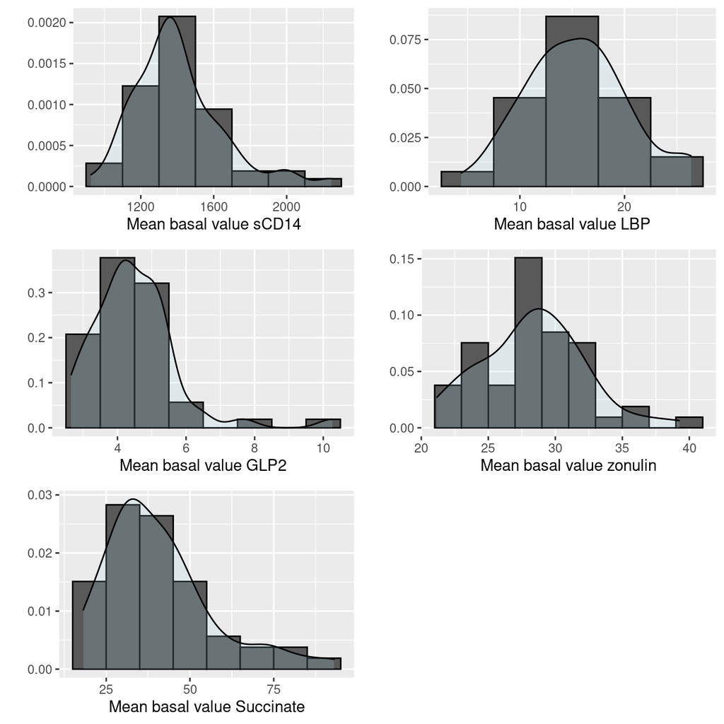

```r
> do.call(grid.arrange, hist.list.IP[grep("basalmean", colnames(IP)[7:ncol(IP)])])
```

All mean basal values for the variables in this dataset follows a right skewed distribution, except the mean basal value of `LBP`.

Now let’s take a look at the main relationships between them and the BMI.

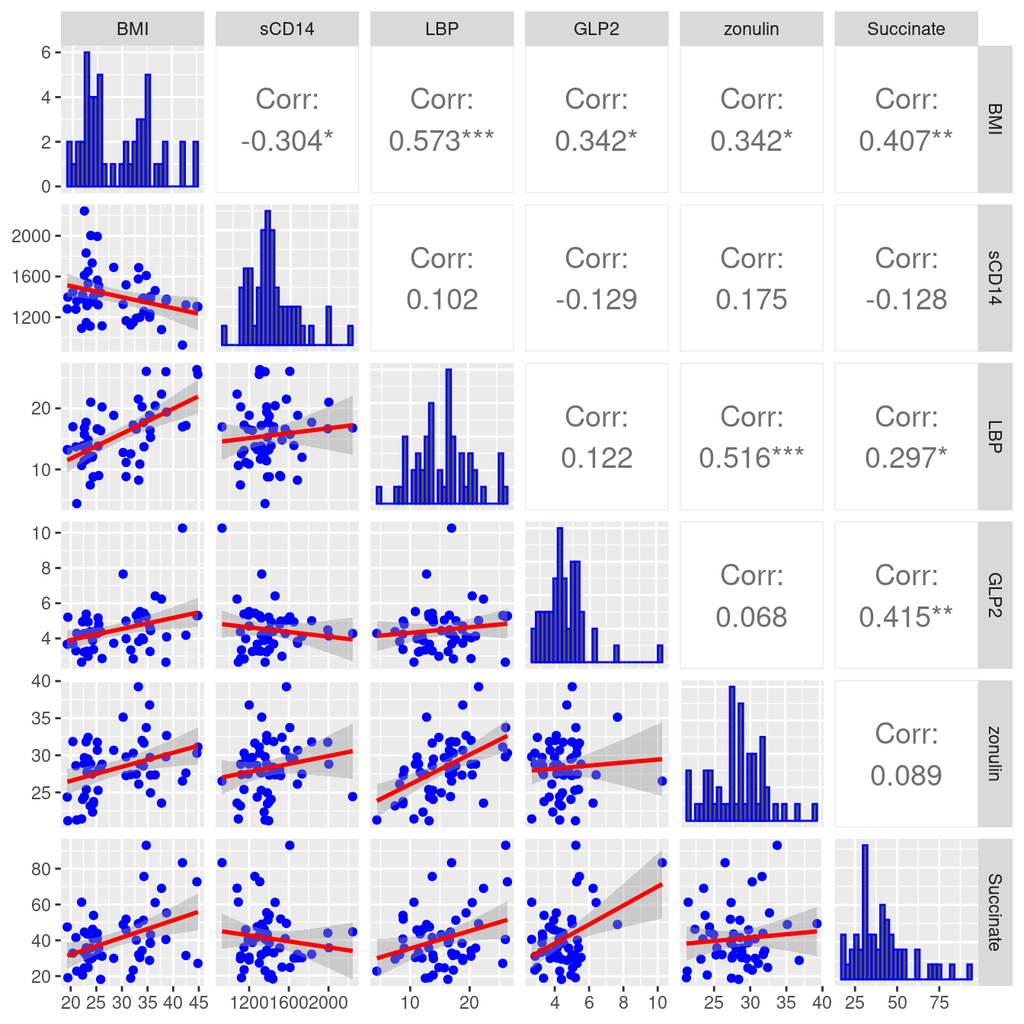

```r
> ggpairs(IP[, c(6, grep("basalmean", colnames(IP)))], lower = list(continuous = wrap(lowerFn,
+     method = "lm")), diag = list(continuous = wrap("barDiag", colour = "blue")),
+     upper = list(continuous = wrap("cor", size = 5)), columnLabels = c("BMI", "sCD14",
+         "LBP", "GLP2", "zonulin", "Succinate"))
```

In general terms, without making groups, BMI correlates positively with all basal levels of `LBP`, `GLP2`, `zonulin` and `Succinate`. This means, while BMI augments, all levels increases except `CD14` in which the correlation is negative. All correlations are statistically significant.

Regarding, `CD14` none of the correlation is statistically significant, furthermore, barely is there any correlation. Between positive with LBP and `zonulin` and negative for `Succinate` and `GLP2`.

`GLP2` with `zonulin` though the data tells us there is a positive correlation, practically this correlation does not exist. Though is statistical significant positive with `Succinate`. Furthermore `Succinate` and `zonulin` does not correlate.

Now, we are going to proceed to observe the different values of each variable at basal, Postprandial and between the different days.

##### CD14

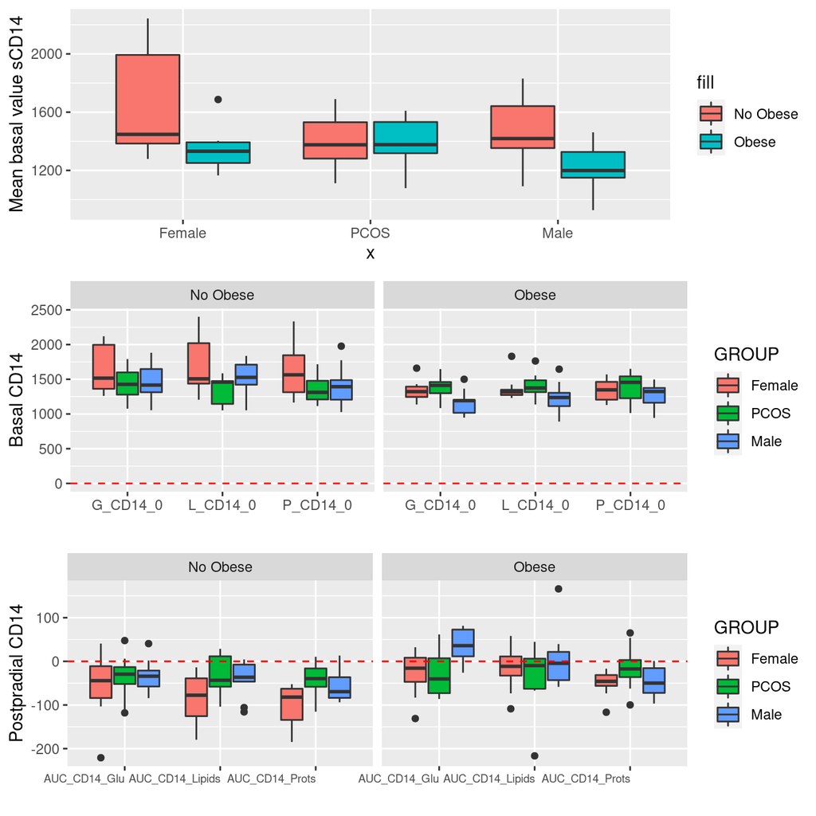

```r
> cd14_basal <- bp.interaction[1]
> p1 <- bp.1.vars(IP, c("G_CD14_0", "L_CD14_0", "P_CD14_0"), "Basal CD14")
> p2 <- bp.1.vars(IP, c("AUC_CD14_Glu", "AUC_CD14_Lipids", "AUC_CD14_Prots"), "Postpradial CD14") +
+     theme(axis.text.x = element_text(angle = 0, vjust = 0.9, hjust = 1, size = 7))
> grid.arrange(cd14_basal[[1]], p1, p2)
```

Postpradial levels of `CD14` are lower than basal levels of this permeability marker. Non-obese women have higher values of `CD14` at basal stage, followed by non-obese men. Obese PCOS women, have the highest values between obese subjects, but lower than healthy women, and similar values in non-obese PCOS women. Obese men and obese women, have lower levels than non-obese subjects. Postpradial levels, are lower in non-obese subjects, being lower women. Obese men at the first day have the highest values.

##### LBP

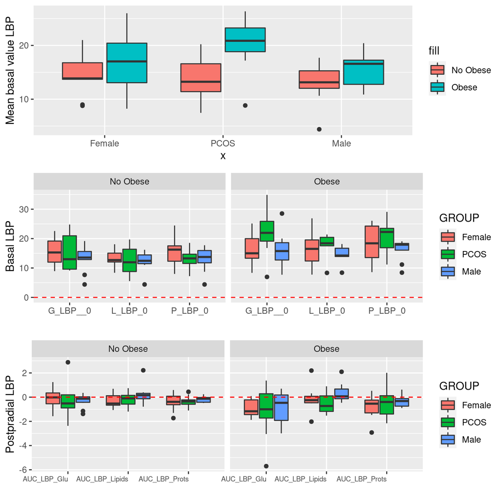

```r
> lbp_basal <- bp.interaction[8][[1]]
> p1 <- bp.1.vars(IP, c("G_LBP__0", "L_LBP_0", "P_LBP_0"), "Basal LBP")
> p2 <- bp.1.vars(IP, c("AUC_LBP_Glu", "AUC_LBP_Lipids", "AUC_LBP_Prots"), "Postpradial LBP") +
+     theme(axis.text.x = element_text(angle = 0, vjust = 0.9, hjust = 1, size = 7))
> grid.arrange(lbp_basal, p1, p2)
```

Basal levels of `LBP` are higher than Postpradial stage. The IP data tells us that the mean basal values are higher in obese subjects, but mostly on PCOS obese women. At Postpradial stage, higher values have the non.obese subjects, but with more variability in obese subjects. Obese men at the lipid load day, have the highest values at Postprandial levels. In general at Postpradial stage the levels are similar between non-obese subjects.

##### GLP

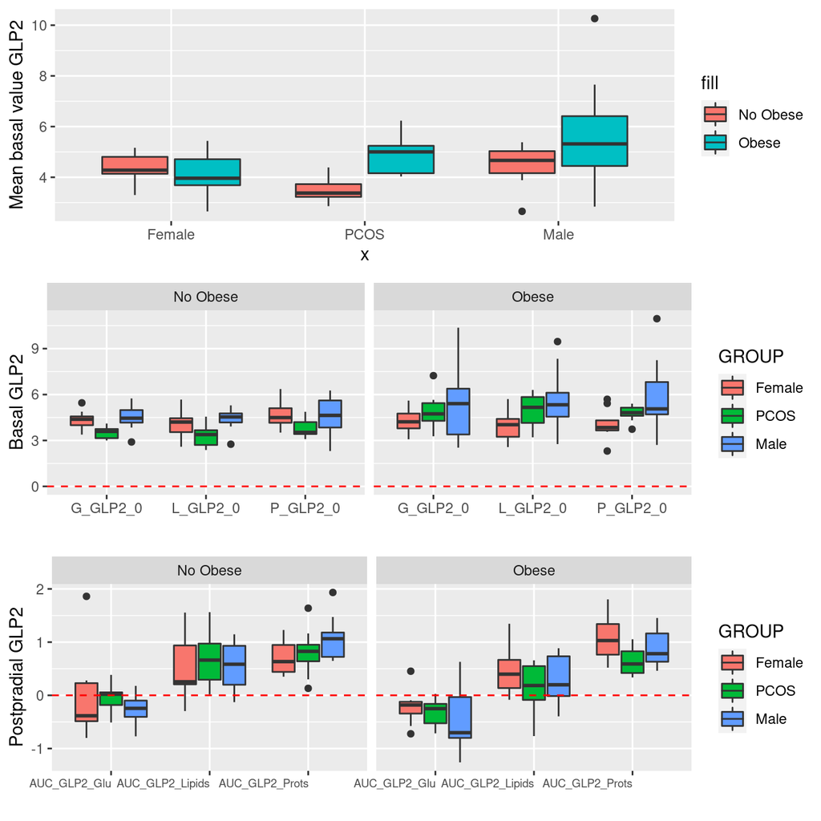

```r
> lbp_basal <- bp.interaction[15][[1]]
> p1 <- bp.1.vars(IP, c("G_GLP2_0", "L_GLP2_0", "P_GLP2_0"), "Basal GLP2")
> p2 <- bp.1.vars(IP, c("AUC_GLP2_Glu", "AUC_GLP2_Lipids", "AUC_GLP2_Prots"), "Postpradial GLP2") +
+     theme(axis.text.x = element_text(angle = 0, vjust = 0.9, hjust = 1, size = 7))
> grid.arrange(lbp_basal, p1, p2)
```

Again, basal levels of `GLP2` are higher than at Postpradial stage. Regarding the mean basal values, we observe that the obese PCOS and men have higher values. Control females, both obese and non-obese have similar distribution of values. While healthy males and PCOS obese women have similar values. If we see the data at the different days, on non-obese PCOS women, these patients have the lower values.

At Postpradial time, in general, across subjects, the valuesof `GLP2` increases at the lipid and protein levels progressively. With similar values between subjects on non-obese persons. Obese PCOS women, show lower values of `GLP2`.

##### zonulin

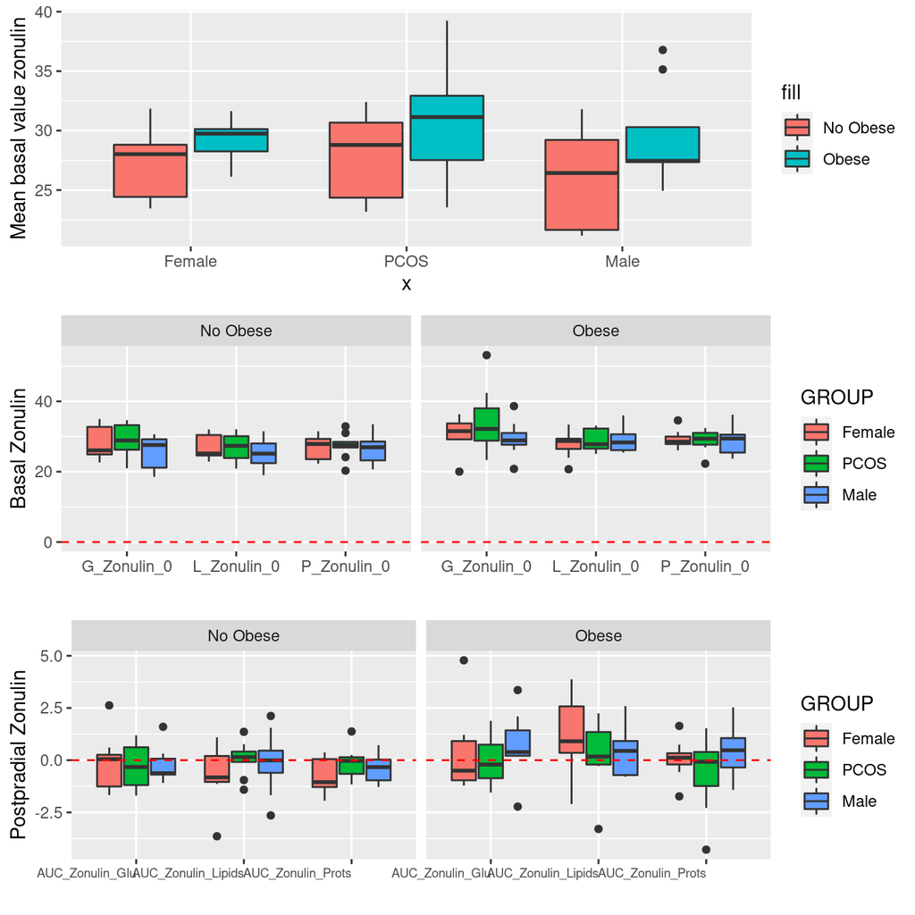

```r
> lbp_basal <- bp.interaction[22][[1]]
> p1 <- bp.1.vars(IP, c("G_Zonulin_0", "L_Zonulin_0", "P_Zonulin_0"), "Basal Zonulin")
> p2 <- bp.1.vars(IP, c("AUC_Zonulin_Glu", "AUC_Zonulin_Lipids", "AUC_Zonulin_Prots"),
+     "Postpradial Zonulin") + theme(axis.text.x = element_text(angle = 0, vjust = 0.9,
+     hjust = 1, size = 7))
> grid.arrange(lbp_basal, p1, p2)
```

Basal levels of `zonulin` are higher than Postpradial levels. The mean basal levels are higher in obese subjects, but higher in obese women with PCOS. This values are higher at basal levels on the glucose load day. Similar values at Postpradial time or non-obese subjects is observed. Meanwhile on obese subjects these values increases. At glucose load day, the higher levels are in obese men. Next day and, in overall, obese control females have the highest concentration of `zonulin`, meanwhile the last day again, obese men have the higher value.

##### Succinate.

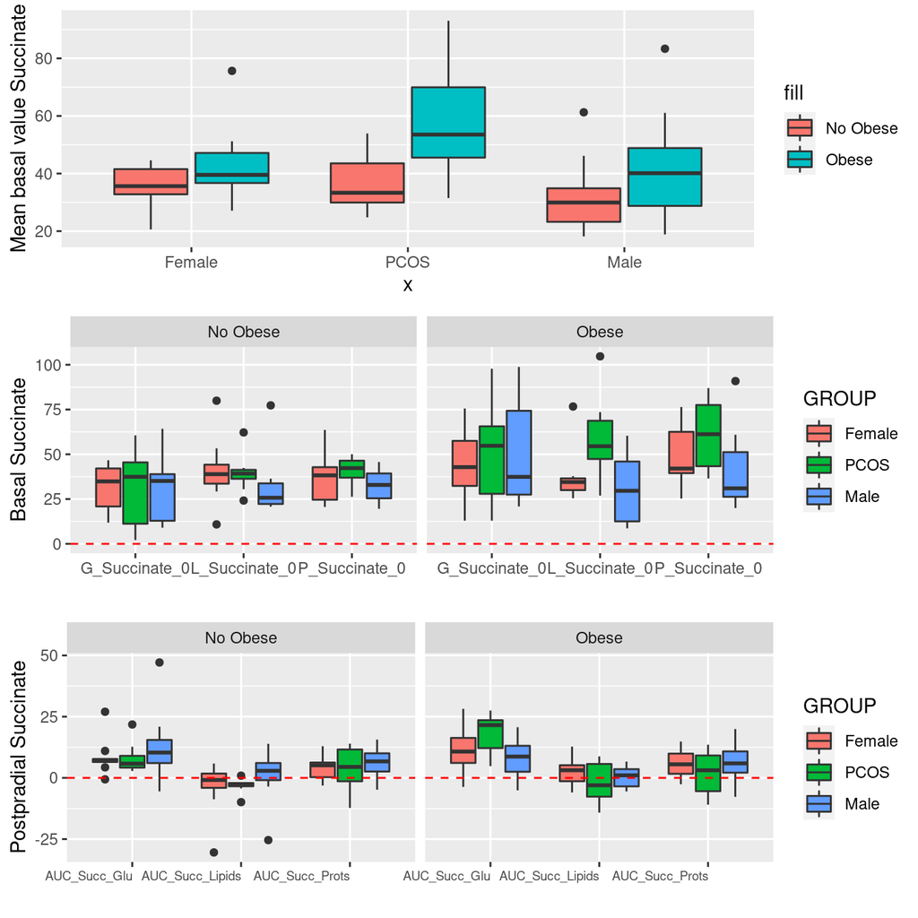

```r
> lbp_basal <- bp.interaction[29][[1]]
> p1 <- bp.1.vars(IP, c("G_Succinate_0", "L_Succinate_0", "P_Succinate_0"), "Basal Succinate")
> p2 <- bp.1.vars(IP, c("AUC_Succ_Glu", "AUC_Succ_Lipids", "AUC_Succ_Prots"), "Postpradial Succinate") +
+     theme(axis.text.x = element_text(angle = 0, vjust = 0.9, hjust = 1, size = 7))
> grid.arrange(lbp_basal, p1, p2)
```

Basal concentration levels of `succinate` are higher than Postprandial levels. This levels are higher in obese subjects, particularly on PCOS women. At Postpradial time, non-obese males, have higher values, being this concentration higher on the first day. On obese subjects, also, the higher values are at the first day, with PCOS obese females with higher concentration, even in comparison with non-obese subjects.

## Statistical multivariate descriptive analysis.

We are going to perform a dimensionality reduction approach. Because, we are only interested on the visualization of the variables, we did not perform corroboration of the assumptions underlying PCA. Apart from the IP markers, we are also going to compute the PCA with the BMi variable.

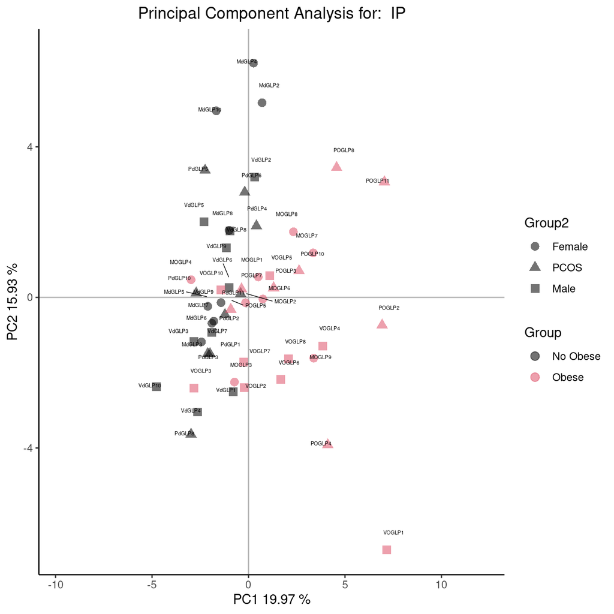

```r
> X <- IP[, 6:ncol(IP)]
> res <- plotPCA_scores(X, list(IP$OBESE, IP$GROUP), title = "IP", center_ = T, scale_ = T,
+     labels = IP$Paciente)
> res[[2]]
```

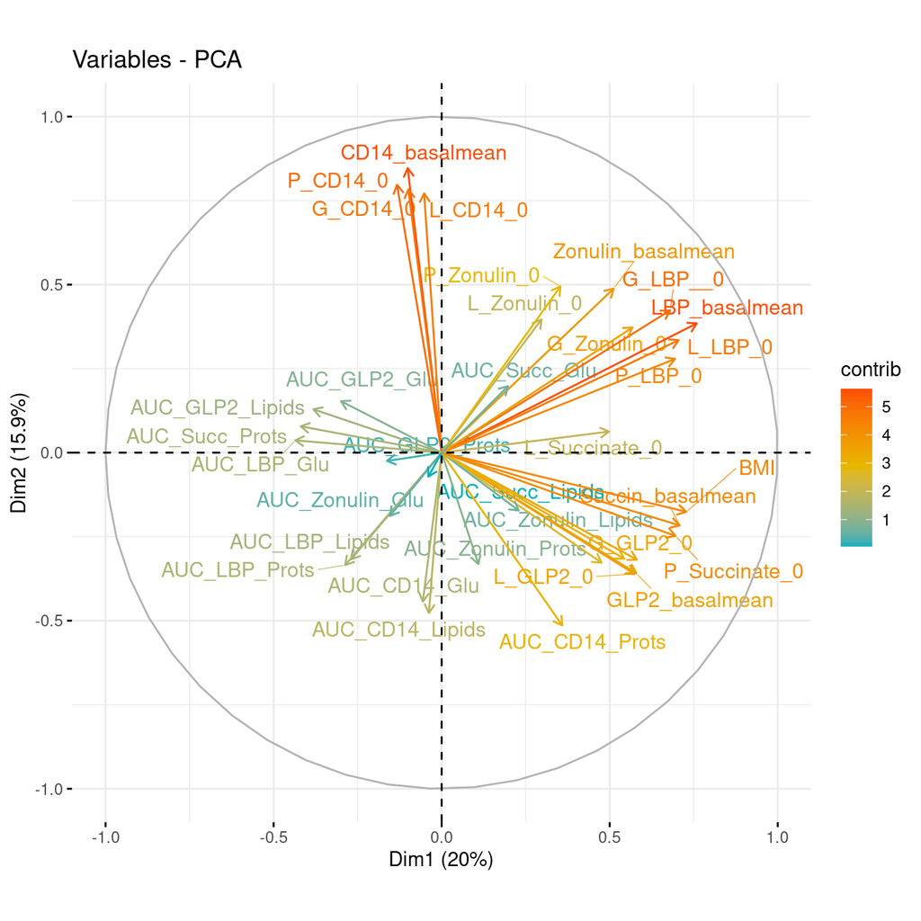

```r
>   fviz_pca_var(res[[1]],
+     col.var = "contrib", # Color by contributions to the PC
+     gradient.cols = c("#00AFBB", "#E7B800", "#FC4E07"),
+
+   repel = TRUE
+ # Avoid text overlapping
+ )
```